# Arrival Delay Prediction

Priya Rangarajan

###### The notebook includes code to Visualize, Prepare and Model data on flights in the first quarter of 2018 in United States for Destination airports ORD and ATL. Various stages of Predictive Modeling from Data Visualization and Preparation to Feature Engineering and Model Training and Evaluation have been implemented to predict arrival delays for flights.

## Table of Contents:

1. EDA  
   *Import Libraries and Read Data*  
   Exploring Delays and Cause of Delays
2. Data Cleaning, Preparation and Feature Engineering  
   *Check and Remove Missing Data*  
   Add Day of Week and Month  
   *Create Arrival and Departure Bins*  
   Create Binary Target Variable  
   *Correlation check and Outliers*  
   One Hot Encoding
3. Modeling  
   *Train Test Split*  
   Sampling Class Imbalance  
   *Logistic Regression*  
   Random Forest Classifier  
   *Stochastic Gradient Classifier*  
   Decision Tree Classifier  
   *Gradient Boost Classifier*  
   ROC Curve and Model Performance Comparison  
   *Grid Search and Fine Tuning*  
   Model Evaluation on Test Data

## Exploratory Analysis

### Import Libraries and Read Data

```python
import datetime, warnings, scipy
import pandas as pd
import numpy as np
import seaborn as sns
import matplotlib.pyplot as plt
import datetime as dt
from scipy.stats import norm,skew
from scipy import stats
%matplotlib inline
warnings.filterwarnings("ignore")
```

```python
data = pd.read_csv("master_data.csv")
```

```python
pd.set_option('display.max_columns',None)
data.head()
```

|  | fl_date | op_unique_carrier | tail_num | op_carrier_fl_num | origin | dest | dep_time | dep_delay | taxi_out | taxi_in | arr_time | arr_delay | cancelled | actual_elapsed_time | air_time | distance | carrier_delay | weather_delay | nas_delay | security_delay | late_aircraft_delay |
| --- | --- | --- | --- | --- | --- | --- | --- | --- | --- | --- | --- | --- | --- | --- | --- | --- | --- | --- | --- | --- | --- |
| 0 | 2018-03-01 | F9 | N223FR | 426 | DEN | ATL | 2011.0 | -4.0 | 13.0 | 7.0 | 46.0 | -26.0 | 0 | 155.0 | 135.0 | 1199 | NaN | NaN | NaN | NaN | NaN |
| 1 | 2018-03-01 | F9 | N227FR | 1286 | DEN | ORD | 624.0 | -6.0 | 34.0 | 12.0 | 1001.0 | -4.0 | 0 | 157.0 | 111.0 | 888 | NaN | NaN | NaN | NaN | NaN |
| 2 | 2018-03-01 | F9 | N232FR | 1480 | LAX | ATL | 1026.0 | 63.0 | 17.0 | 9.0 | 1738.0 | 49.0 | 0 | 252.0 | 226.0 | 1947 | 0.0 | 0.0 | 0.0 | 0.0 | 49.0 |
| 3 | 2018-03-01 | F9 | N312FR | 1567 | TTN | ATL | 736.0 | -4.0 | 11.0 | 5.0 | 944.0 | -19.0 | 0 | 128.0 | 112.0 | 701 | NaN | NaN | NaN | NaN | NaN |
| 4 | 2018-03-01 | F9 | N322FR | 1465 | LGA | ATL | 1800.0 | 0.0 | 34.0 | 9.0 | 2048.0 | -6.0 | 0 | 168.0 | 125.0 | 762 | NaN | NaN | NaN | NaN | NaN |

```python
data.shape
```

```
(166193, 21)
```

### Exploring Delays and Cause of Delays

```python
data.drop(data.loc[data['dest']=='HGR'].index,inplace = True)
```

Include only ORD and ATL for destination Airports

```python
data = data.drop(['op_carrier_fl_num','tail_num'],axis=1)
```

Drop Columns not required for analysis

```python
data['op_unique_carrier'].loc[data['op_unique_carrier']=='AA'] = 'American Airlines'
data['op_unique_carrier'].loc[data['op_unique_carrier']=='9E'] = 'Endeavor Air'
data['op_unique_carrier'].loc[data['op_unique_carrier']=='AS'] = 'Alaska Airlines'
data['op_unique_carrier'].loc[data['op_unique_carrier']=='DL'] = 'Delta Airlines'
data['op_unique_carrier'].loc[data['op_unique_carrier']=='OO'] = 'SkyWest Airlines'
data['op_unique_carrier'].loc[data['op_unique_carrier']=='UA'] = 'United Airlines'
data['op_unique_carrier'].loc[data['op_unique_carrier']=='MQ'] = 'Envoy Air'
data['op_unique_carrier'].loc[data['op_unique_carrier']=='WN'] = 'Southwest Airlines'
data['op_unique_carrier'].loc[data['op_unique_carrier']=='YX'] = 'Republic Airlines'
data['op_unique_carrier'].loc[data['op_unique_carrier']=='EV'] = 'ExpressJet Airlines'
data['op_unique_carrier'].loc[data['op_unique_carrier']=='NK'] = 'Spirit Airlines'
data['op_unique_carrier'].loc[data['op_unique_carrier']=='F9'] = 'Frontier Airlines'
data['op_unique_carrier'].loc[data['op_unique_carrier']=='B6'] = 'JetBlue Airways'
data['op_unique_carrier'].loc[data['op_unique_carrier']=='OH'] = 'PSA Airlines'
data['op_unique_carrier'].loc[data['op_unique_carrier']=='YV'] = 'Mesa Airlines'
data['op_unique_carrier'].loc[data['op_unique_carrier']=='VX'] = 'Virgin America'
```

Replace abbreivations with Carrier names

```python
data['dest'].value_counts()
```

```
ATL    91298
ORD    74870
Name: dest, dtype: int64
```

Check destination only has ORD and ATL airports

#### Arrival and Departure Delays by Airline Carrier

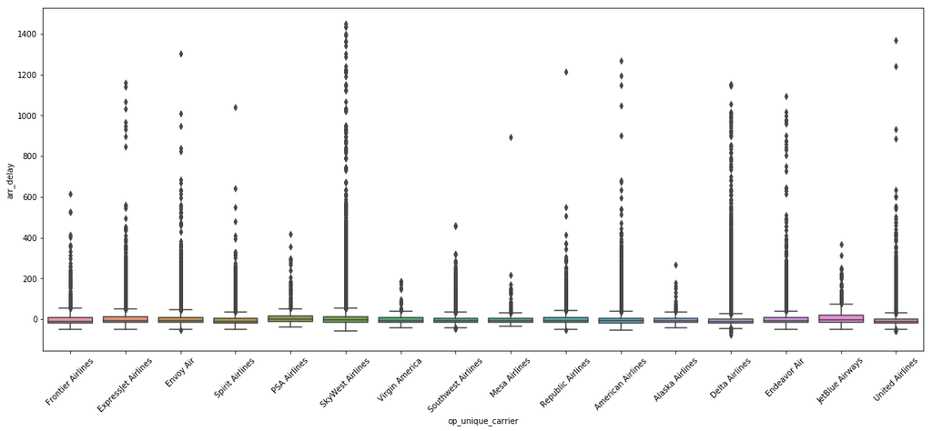

```python
f, ax = plt.subplots(figsize=(20, 8))
plt.xticks(rotation='45')
fig = sns.boxplot(x="op_unique_carrier",y="arr_delay",data=data)
```

Skywest, American Airlines and United Airlines have high Arrival Delays

```python
air_arrival_delay = pd.DataFrame({'avg_arrival_delay' : data.groupby(['op_unique_carrier'])['arr_delay'].mean()}).reset_index()
air_dep_delay = pd.DataFrame({'avg_departure_delay' : data.groupby(['op_unique_carrier'])['dep_delay'].mean()}).reset_index()
```

```python
arr_delay = pd.merge( data,air_arrival_delay, left_on='op_unique_carrier', right_on='op_unique_carrier', how='left')
dep_delay = pd.merge(data,air_dep_delay , left_on='op_unique_carrier', right_on='op_unique_carrier', how='left')
```

```python
df_delay = data[~np.isnan(data['arr_delay'])]
df_delay['arr_delay'].fillna(0, inplace=True)
```

```
Text(0.5,1,'Arrival vs Departure Delays by Carrier')
```

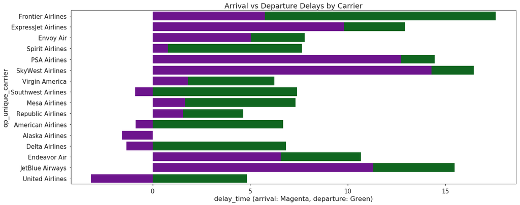

```python
f, ax = plt.subplots(figsize=(20, 8))
ax = sns.set_color_codes("dark")
sns.set_context("notebook", font_scale=1.5)
ax = sns.barplot(x="avg_departure_delay", y="op_unique_carrier", data= dep_delay,
            label="accuracy", color="g")
ax = sns.barplot(x="avg_arrival_delay", y="op_unique_carrier", data= arr_delay,
            label="accuracy", color="m")
ax.set(xlabel="delay_time (arrival: Magenta, departure: Green)")
ax.set_title("Arrival vs Departure Delays by Carrier")
```

Airline Carriers have higher Departure Delays in comparison to Arrival Delays

```python
carrier_delay = df_delay['carrier_delay'].groupby(df_delay['op_unique_carrier']).mean()
weather_delay = df_delay['weather_delay'].groupby(df_delay['op_unique_carrier']).mean()
nas_delay= df_delay['nas_delay'].groupby(df_delay['op_unique_carrier']).mean()
security_delay =df_delay['security_delay'].groupby(df_delay['op_unique_carrier']).mean()
late_delay = df_delay['late_aircraft_delay'].groupby(df_delay['op_unique_carrier']).mean()
carrier_delay.values
```

```
array([ 8.98684211, 19.49155146, 24.91052171, 29.68984446, 17.68216756,
       22.91423002, 19.99636364, 28.56949153, 25.01234568, 23.04494382,
       11.17512438, 27.66186253, 14.56147832, 13.8125    , 15.09159537,
       23.18421053])
```

```python
c_val = carrier_delay.values
w_val = c_val + weather_delay.values
```

```python
nas_val = w_val + nas_delay.values
sec_val = nas_val + security_delay.values
```

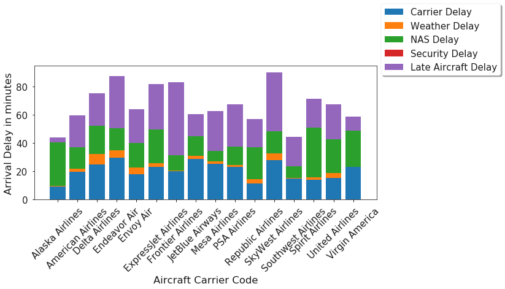

```python
x = carrier_delay.index.values

fig, ax = plt.subplots(figsize = (10,4))

ax.set_xticks(np.arange(len(x)))
ax.set_xticklabels(x, rotation = 45)
ax.bar(np.arange(len(x)),carrier_delay.values, align='center', label='Carrier Delay')
ax.bar(np.arange(len(x)),weather_delay.values, align='center', bottom=c_val, label='Weather Delay')
ax.bar(np.arange(len(x)),nas_delay.values, align='center', bottom=w_val, label='NAS Delay')
ax.bar(np.arange(len(x)),security_delay.values, align='center', bottom=nas_val, label='Security Delay')
ax.bar(np.arange(len(x)),late_delay.values, align='center', bottom=sec_val, label='Late Aircraft Delay')

ax.set_xlabel('Aircraft Carrier Code')
ax.set_ylabel('Arrival Delay in minutes')
plt.legend()
ax.legend(bbox_to_anchor=(1.0, 1.5),
          ncol=1, fancybox=True, shadow=True)


plt.show()
```

Late Aircraft Delays contribute to most of the Arrival Delays

## Data Cleaning , Preparation and Feature Engineering

#### Check and Remove Missing Data

```python
df = data.copy()
```

```python
miss_cols = df.isnull().sum().sort_values(ascending = False)
percent = (df.isnull().sum()/df.isnull().count()).sort_values(ascending=False)
missing_data = pd.concat([miss_cols, percent], axis=1, keys=['Missing Columns', 'Percent'])
missing_data.head(20)
```

|  | Missing Columns | Percent |
| --- | --- | --- |
| late_aircraft_delay | 140587 | 0.846053 |
| security_delay | 140587 | 0.846053 |
| nas_delay | 140587 | 0.846053 |
| weather_delay | 140587 | 0.846053 |
| carrier_delay | 140587 | 0.846053 |
| arr_delay | 3943 | 0.023729 |
| air_time | 3849 | 0.023163 |
| actual_elapsed_time | 3849 | 0.023163 |
| dep_delay | 3769 | 0.022682 |
| arr_time | 3674 | 0.022110 |
| taxi_in | 3674 | 0.022110 |
| taxi_out | 3662 | 0.022038 |
| dep_time | 3597 | 0.021647 |
| cancelled | 0 | 0.000000 |
| distance | 0 | 0.000000 |
| dest | 0 | 0.000000 |
| origin | 0 | 0.000000 |
| op_unique_carrier | 0 | 0.000000 |
| fl_date | 0 | 0.000000 |

```python
df = df.dropna(subset=['arr_time'])
```

Create copy of data

```python
df['arr_time'] = df['arr_time'].astype('int64')
df['dep_time'] = df['dep_time'].astype('int64')
```

Remove missing values in Arrival and Departure Times

```python
df = df.dropna(subset=['arr_delay'])
df2 = df.dropna(subset = ['dep_delay'])
df_final = df2.fillna(0)
```

Check for missing values in Data

Missing values in Delay Reasons filled with zero , removed other missing values as they contribute only 2 percent of the data

#### Add day of week and month columns

```python
df_final['month'] = pd.DatetimeIndex(df_final['fl_date']).month
df_final['Day of Week'] = pd.DatetimeIndex(df_final['fl_date']).weekday_name
```

Extract month from date column ; Extract day of week

#### Create Bins for Arrival and Departure Times

```python
def create_time_bins(time):
    if time < '0359':
       return "LateNight"
    elif time < '0659':
        return "EarlyMorning"
    elif time < '1159':
        return "Morning"
    elif time < '1559':
        return "Afternoon"
    elif time < '2259':
        return "Evening"
    else:
        return "LateNight"
```

```python
df_final['arr_time'] = df_final['arr_time'].astype('str')
df_final['ARR_TIME_BIN'] = df_final['arr_time'].apply(create_time_bins).astype('category')
df_final['dep_time'] = df_final['dep_time'].astype('str')
df_final['DEP_TIME_BIN'] = df_final['dep_time'].apply(create_time_bins).astype('category')
```

Create time bins for Arrival and Departure time

```python
months = {1:'Jan',  2:'Feb',  3:'Mar'}
df_final['month'] = df_final['month'].map(months)
```

Convert Month from number to Name of Month

#### Create Binary Target Variable

```python
def create_target(target):
    if target <= 0.0:
       return 0
    else:
        return 1
```

Create Target variable for Binary Classification 0 - Not Delayed(Positive Class) ; 1 - Delayed(Negative Class)

```python
df_final['Arr_Target'] = df_final['arr_delay'].apply(create_target).astype('category')
cols = ['fl_date','dep_time','arr_time','arr_delay']
df_final.drop(cols, inplace=True, axis=1)
df_final['Dep_delay'] = df_final['dep_delay'].apply(create_target).astype('category')
df_prep = df_final.drop(['dep_delay'],axis=1)
df_prep['cancelled'] = df_prep['cancelled'].astype('str')
```

```
Text(0.5,1,'Arrival Delays by Time of Arrival')
```

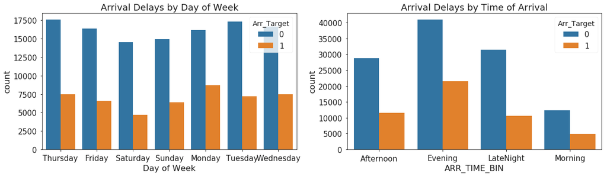

```python
fig, (ax1,ax2) = plt.subplots(1,2,figsize=(20,5))
sns.countplot(x="Day of Week", hue="Arr_Target", data=df_prep,ax=ax1)
sns.countplot(x="ARR_TIME_BIN", hue="Arr_Target", data=df_prep,ax=ax2)
ax1.set_title("Arrival Delays by Day of Week")
ax2.set_title("Arrival Delays by Time of Arrival")
```

Monday have maximum arrival delays. Evenings have higher arrival delays

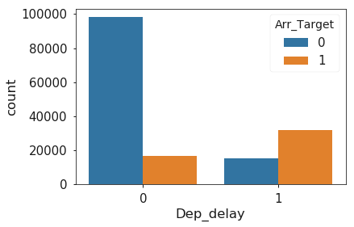

```python
sns.countplot(x="Dep_delay", hue="Arr_Target", data=df_prep)
```

```python
ix = df_prep['origin'].value_counts().index[:100]
df_prep['origin'] = np.where(df_prep['origin'].isin(ix), df_prep['origin'], 'OTHER')
```

Condense Origin category to reduce categories and condense categories with lesser counts to 'Other'

#### Correlation Check and Skewness in Numerical Variables

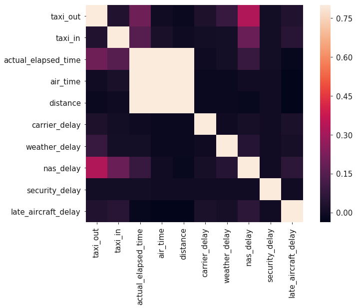

```python
## Correlation plot
corrmat = df_prep.corr()
f, ax = plt.subplots(figsize=(12, 8))
sns.heatmap(corrmat, vmax=.8, square=True);
```

```python
df_prep = df_prep.drop(['actual_elapsed_time'],axis=1)
```

Distance and Actual Elapsed time are highly correlated. We will thus retain only one of them

```python
df_prep = df_prep.drop(['air_time'],axis=1)
```

```python
df_prep['Taxi_time'] = df_prep.taxi_out+df_prep.taxi_in
df_prep = df_prep.drop(['taxi_in','taxi_out'],axis=1)
```

Combine Taxi In and Taxi Out times as one feature

```python
df_prep['Arr_Target'].value_counts()
```

```
0    113523
1     48537
Name: Arr_Target, dtype: int64
```

```
 mu = 688.07 and sigma = 483.70
```

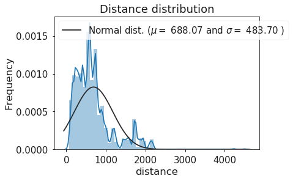

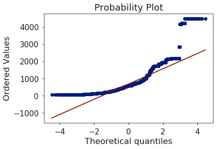

```python
sns.distplot(df_prep['distance'],fit = norm)
(mu, sigma) = norm.fit(df_prep['distance'])
print( '\n mu = {:.2f} and sigma = {:.2f}\n'.format(mu, sigma))

#Now plot the distribution
plt.legend(['Normal dist. ($\mu=$ {:.2f} and $\sigma=$ {:.2f} )'.format(mu, sigma)],
            loc='upper left')
plt.ylabel('Frequency')
plt.title('Distance distribution')

#Get also the QQ-plot
fig = plt.figure()
res = stats.probplot(df_prep['distance'], plot=plt)
plt.show()
```

```
 mu = 28.42 and sigma = 12.39
```

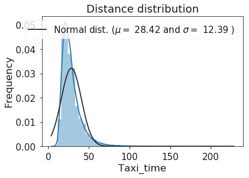

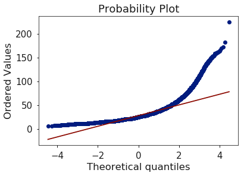

```python
sns.distplot(df_prep['Taxi_time'],fit = norm)
(mu, sigma) = norm.fit(df_prep['Taxi_time'])
print( '\n mu = {:.2f} and sigma = {:.2f}\n'.format(mu, sigma))

#Now plot the distribution
plt.legend(['Normal dist. ($\mu=$ {:.2f} and $\sigma=$ {:.2f} )'.format(mu, sigma)],
            loc='best')
plt.ylabel('Frequency')
plt.title('Distance distribution')

#Get also the QQ-plot
fig = plt.figure()
res = stats.probplot(df_prep['Taxi_time'], plot=plt)
plt.show()
```

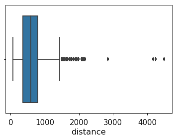

```python
sns.boxplot(x=df_prep["distance"])
```

```python
skew(df_prep['distance'])
```

```
1.7756028619407491
```

```python
from scipy.special import boxcox1p
lam = 0.15
df_prep['distance'] = boxcox1p(df_prep['distance'], lam)
```

Apply Box cox tranformation for distance variable to convert to normal form

#### One hot Encoding of Categorical Variables

```python
cols_cat = ['op_unique_carrier','origin','dest','month','ARR_TIME_BIN','DEP_TIME_BIN']
df_dummies = pd.get_dummies(df_prep[cols_cat],drop_first = True)
```

One-Hot Encode categorical variables for modeling

```python
cols_num=['Taxi_time','distance','cancelled','carrier_delay','weather_delay','nas_delay','security_delay','late_aircraft_delay','Dep_delay','Arr_Target']
df_num = df_prep[cols_num]
df_num.head()
```

|  | Taxi_time | distance | cancelled | carrier_delay | weather_delay | nas_delay | security_delay | late_aircraft_delay | Dep_delay | Arr_Target |
| --- | --- | --- | --- | --- | --- | --- | --- | --- | --- | --- |
| 0 | 20.0 | 12.643496 | 0 | 0.0 | 0.0 | 0.0 | 0.0 | 0.0 | 0 | 0 |
| 1 | 46.0 | 11.793857 | 0 | 0.0 | 0.0 | 0.0 | 0.0 | 0.0 | 0 | 0 |
| 2 | 26.0 | 14.099058 | 0 | 0.0 | 0.0 | 0.0 | 0.0 | 49.0 | 1 | 1 |
| 3 | 16.0 | 11.151348 | 0 | 0.0 | 0.0 | 0.0 | 0.0 | 0.0 | 0 | 0 |
| 4 | 43.0 | 11.375447 | 0 | 0.0 | 0.0 | 0.0 | 0.0 | 0.0 | 0 | 0 |

```python
df_data = pd.concat([df_num,df_dummies],axis=1)
```

## Modeling

#### Train, Validation and Test Split

```python
df_data = df_data.sample(n=len(df_dummies))
df_data = df_data.reset_index(drop = True)
```

Shuffle the data to avoid any specific order of samples in the data

```python
df_val_test = df_data.sample(frac=0.3)
df_test = df_val_test.sample(frac = 0.5)
df_val = df_val_test.drop(df_test.index)
```

Get 30 percent of data for Validation and Test sets; Split the data into half to get Test and Valiation sets

```python
df_train = df_data.drop(df_val_test.index)
```

Get training data

```python
def calc_bal (var):
    return(sum(var)/len(var))
print('Test balance(n = %d):%.3f'%(len(df_test),calc_bal(df_test.Arr_Target.values)))
print('Validation balance(n = %d):%.3f'%(len(df_val),calc_bal(df_val.Arr_Target.values)))
print('Train balance(n = %d):%.3f'%(len(df_train),calc_bal(df_train.Arr_Target.values)))
```

```
Test balance(n = 24309):0.295
Validation balance(n = 24309):0.299
Train balance(n = 113442):0.301
```

Check for class balance in output variable across training,test and validation samples

```python
X_train = df_train.drop(['Arr_Target'],axis=1)
Y_train = df_train.Arr_Target
X_val = df_val.drop(['Arr_Target'],axis =1)
Y_val = df_val.Arr_Target
```

Split into X and Y for dependent and Target variables

```python
X = pd.concat([X_train,Y_train], axis=1)
```

#### Sampling Target Variable to remove Class Imbalance

```python
X['Arr_Target'].value_counts()
Delayed = X[X.Arr_Target == 1]
Not_Delayed = X[X.Arr_Target ==0]
from sklearn.utils import resample
upsampled = resample(Delayed,
                          replace=True, # sample with replacement
                          n_samples=len(Not_Delayed), # match number in majority class
                          random_state=27)
sampled = pd.concat([Not_Delayed, upsampled])
```

```python
y_train = sampled.Arr_Target
x_train= sampled.drop('Arr_Target', axis=1)
```

Data has class imbalance. So we oversample the underrepresented class

```python
from sklearn.metrics import roc_auc_score,accuracy_score,precision_score,recall_score,f1_score
def cal_spec(y_actual,y_pred,thresh):
    return sum((y_pred < thresh) & (y_actual == 0)) / sum(y_actual == 0)

def print_rep(y_actual,y_pred,thresh):
    auc = roc_auc_score(y_actual,y_pred)
    accuracy = accuracy_score(y_actual,(y_pred > thresh))
    recall = recall_score(y_actual,(y_pred > thresh))
    precision = precision_score(y_actual,(y_pred > thresh))
    specificity = cal_spec(y_actual,y_pred,thresh)
    f1score = f1_score(y_actual,y_pred)
    print('AUC:%.3f'%auc)
    print('Accuracy:%.3f'%accuracy)
    print('Recall:%.3f'%recall)
    print('Specificity:%.3f'%specificity)
    print('Precision:%.3f'%precision)
    print('f1Score:%.3f'%f1score)
    print('')
    return auc,accuracy,recall,precision,specificity,f1score
```

Calculate Model Metrics

#### Logistic Regression

```python
from sklearn.linear_model import LogisticRegression
lr_fit = LogisticRegression(solver='liblinear').fit(x_train, y_train)
y_lr_pred = lr_fit.predict(X_val)
y_train_pred = lr_fit.predict(x_train)
```

```python
from sklearn.metrics import confusion_matrix
confusion_matrix(Y_val,y_lr_pred)
```

```
array([[15101,  1951],
       [ 1245,  6012]], dtype=int64)
```

```python
print_rep(Y_val,y_lr_pred,thresh = 0.5)
```

```
AUC:0.857
Accuracy:0.869
Recall:0.828
Specificity:0.886
Precision:0.755
f1Score:0.790
```

```
(0.8570133866721126,
 0.8685260603068822,
 0.8284415047540306,
 0.7549918372472686,
 0.8855852685901947,
 0.7900131406044678)
```

Confusion Matrix and for Metrics Validation Data

```python
print_rep(y_train,y_train_pred,thresh=0.5)
```

```
AUC:0.858
Accuracy:0.858
Recall:0.828
Specificity:0.887
Precision:0.880
f1Score:0.854
```

```
(0.8579702290172552,
 0.8579702290172551,
 0.828482839461047,
 0.8804045004018216,
 0.8874576185734633,
 0.8536548938629472)
```

Metrics Training Data

```python
from sklearn.model_selection import cross_val_predict
y_cv_lr_train = cross_val_predict(lr_fit,x_train,y_train,cv=5)
y_cv_lr_val = cross_val_predict(lr_fit,X_val,Y_val,cv=5)
```

```python
print_rep(Y_val,y_cv_lr_val,thresh = 0.5)
print_rep(y_train,y_cv_lr_train,thresh=0.5)
```

```
AUC:0.837
Accuracy:0.887
Recall:0.713
Specificity:0.961
Precision:0.887
f1Score:0.791

AUC:0.857
Accuracy:0.857
Recall:0.828
Specificity:0.887
Precision:0.880
f1Score:0.853
```

```
(0.8574093447106719,
 0.8574093447106719,
 0.8279030489418823,
 0.8798237271789652,
 0.8869156404794616,
 0.8530741058209305)
```

```
Text(0.5,0,'Relative Feature Importance')
```

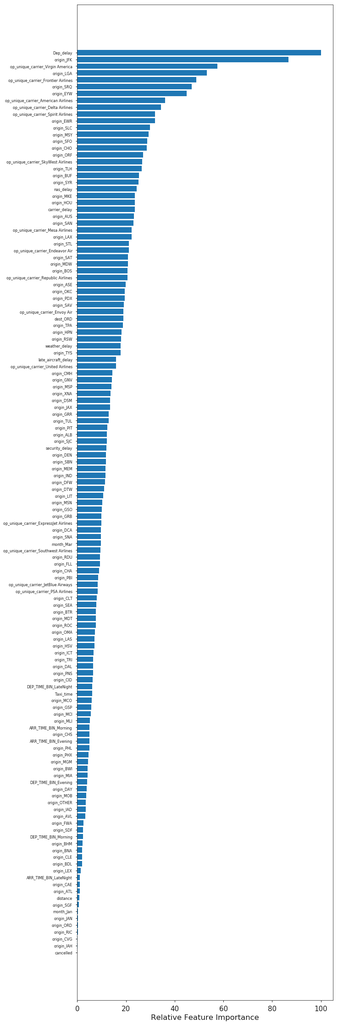

```python
feature_importance = abs(lr_fit.coef_[0])
feature_importance = 100.0 * (feature_importance / feature_importance.max())
sorted_idx = np.argsort(feature_importance)
pos = np.arange(sorted_idx.shape[0]) + .5
featfig = plt.figure(figsize=(10,40))
featax = featfig.add_subplot(1, 1, 1)
featax.barh(pos, feature_importance[sorted_idx], align='center')
featax.set_yticks(pos)
featax.set_yticklabels(np.array(x_train.columns)[sorted_idx], fontsize=8)
featax.set_xlabel('Relative Feature Importance')
```

#### Random Forest Classifier

```python
from sklearn.ensemble import RandomForestClassifier
rf = RandomForestClassifier(n_estimators = 70,max_leaf_nodes = 14,max_depth = 10,n_jobs= -1)
rf.fit(x_train,y_train)
pred_rf = rf.predict(X_val)
```

```python
print_rep(Y_val,pred_rf,thresh = 0.5)
pred_rf_train = rf.predict(x_train)
print_rep(y_train,pred_rf_train,thresh = 0.5)
```

```
AUC:0.832
Accuracy:0.844
Recall:0.802
Specificity:0.862
Precision:0.712
f1Score:0.754

AUC:0.831
Accuracy:0.831
Recall:0.803
Specificity:0.860
Precision:0.851
f1Score:0.826
```

```
(0.8311486154350319,
 0.8311486154350319,
 0.8026947654999432,
 0.8511306532663316,
 0.8596024653701206,
 0.8262034340276202)
```

Metrics Random Forest Classifier

```python
y_cv_rf_train = cross_val_predict(rf,x_train,y_train,cv=5)
y_cv_rf_val = cross_val_predict(rf,X_val,Y_val,cv=5)
print_rep(y_train,y_cv_rf_train,thresh = 0.5)
print_rep(Y_val,y_cv_rf_val,thresh = 0.5)
```

```
AUC:0.834
Accuracy:0.834
Recall:0.780
Specificity:0.887
Precision:0.874
f1Score:0.824

AUC:0.766
Accuracy:0.860
Recall:0.531
Specificity:1.000
Precision:0.999
f1Score:0.694
```

```
(0.7655968097777807,
 0.8599284215722572,
 0.5314868402921318,
 0.9987053340238219,
 0.9997067792634295,
 0.693767425128159)
```

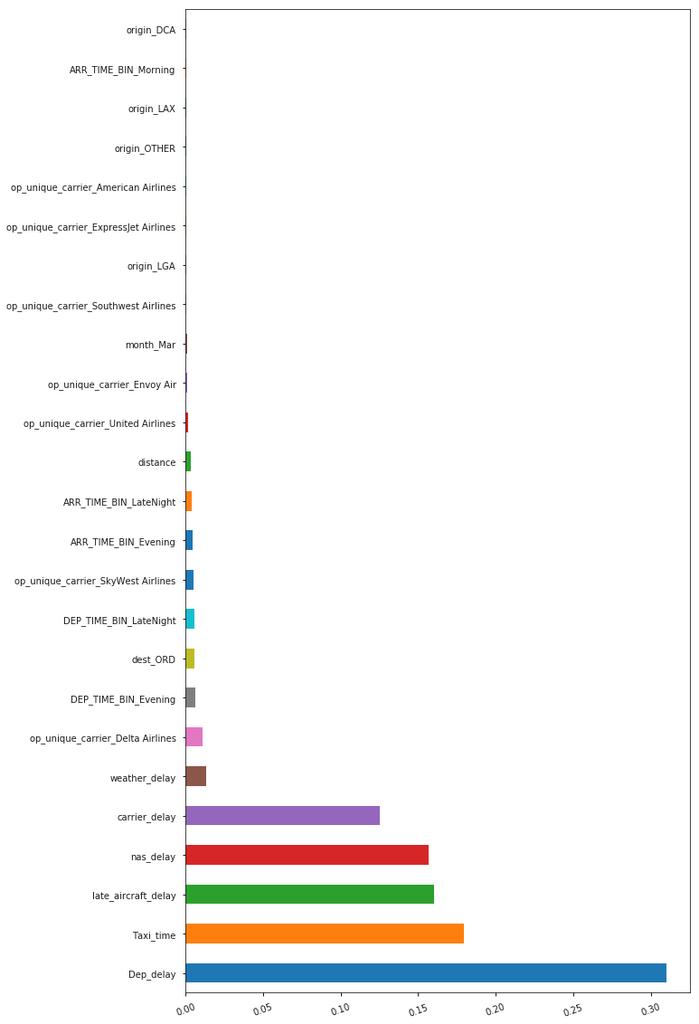

```python
feat_importances = pd.Series(rf.feature_importances_, index=x_train.columns)
plt.figure(figsize=(10,20))
feat_importances.nlargest(25).plot(kind='barh')
plt.xticks(rotation=20, fontsize = 10)
plt.yticks(fontsize = 10)
fig_size = plt.rcParams["figure.figsize"]
```

#### Stochastic Gradient Descent Classifier

```python
from sklearn.linear_model import SGDClassifier
sgdc = SGDClassifier(loss='log',alpha = 0.1)
sgdc_fit = sgdc.fit(x_train,y_train)
pred_sgdc = sgdc.predict(X_val)
```

```python
print_rep(Y_val,pred_sgdc,thresh = 0.5)
```

```
AUC:0.828
Accuracy:0.859
Recall:0.752
Specificity:0.905
Precision:0.771
f1Score:0.761
```

```
(0.8284595416476238,
 0.859393640215558,
 0.7516880253548298,
 0.7714608966199972,
 0.9052310579404176,
 0.7614461194863203)
```

```python
pred_sgdc_train = sgdc.predict(x_train)
print_rep(y_train,pred_sgdc_train,thresh = 0.5)
```

```
AUC:0.826
Accuracy:0.826
Recall:0.748
Specificity:0.905
Precision:0.887
f1Score:0.811
```

```
(0.8263401353684819,
 0.826340135368482,
 0.7476020620375855,
 0.8873363751963498,
 0.9050782086993786,
 0.8114978383407213)
```

```python
##Cross Validation
from sklearn.model_selection import cross_val_predict
y_val_pred_sgc = cross_val_predict(sgdc_fit,x_train,y_train,cv=5)
```

```python
print_rep(y_train,y_val_pred_sgc,thresh = 0.5)
```

```
AUC:0.827
Accuracy:0.827
Recall:0.729
Specificity:0.926
Precision:0.908
f1Score:0.809
```

```
(0.827442997769067,
 0.8274429977690669,
 0.7290109529991555,
 0.9077055869428751,
 0.9258750425389783,
 0.8086034433345682)
```

```python
y_val_sgc = cross_val_predict(sgdc_fit,X_val,Y_val,cv=5)
print_rep(Y_val,y_val_sgc,thresh = 0.5)
```

```
AUC:0.800
Accuracy:0.875
Recall:0.615
Specificity:0.986
Precision:0.949
f1Score:0.746
```

```
(0.8003606918099023,
 0.8751079846970258,
 0.6148546231225024,
 0.9487561131192855,
 0.9858667604973024,
 0.7461538461538461)
```

#### Decision tree Classifier

```python
from sklearn.tree import DecisionTreeClassifier
tree = DecisionTreeClassifier(max_depth=10)
tree.fit(x_train,y_train)
pred_dt_val = tree.predict(X_val)
print_rep(Y_val,pred_dt_val,thresh = 0.5)
```

```
AUC:0.854
Accuracy:0.858
Recall:0.844
Specificity:0.865
Precision:0.726
f1Score:0.781
```

```
(0.8542518388661504,
 0.8584886256119133,
 0.843737081438611,
 0.7264206904733658,
 0.8647665962936899,
 0.7806961621828381)
```

```python
pred_dt_train = tree.predict(x_train)
print_rep(y_train,pred_dt_train,thresh = 0.5)
```

```
AUC:0.863
Accuracy:0.863
Recall:0.856
Specificity:0.869
Precision:0.867
f1Score:0.862
```

```
(0.8625959490288508,
 0.8625959490288508,
 0.8563379926643895,
 0.8671916881525541,
 0.8688539053933122,
 0.8617306655674287)
```

#### Gradient Boosting Classifier

```python
## Gradient Boost
from sklearn.ensemble import GradientBoostingClassifier
gbc = GradientBoostingClassifier(n_estimators = 70,max_depth = 3,learning_rate = 0.8)
gbc_fit = gbc.fit(x_train,y_train)
pred_gbc = gbc.predict(X_val)
```

```python
print_rep(Y_val,pred_gbc,thresh = 0.5)
```

```
AUC:0.862
Accuracy:0.866
Recall:0.850
Specificity:0.873
Precision:0.741
f1Score:0.791
```

```
(0.8615248404389482,
 0.8663046608252087,
 0.8496623949290341,
 0.7406606606606606,
 0.8733872859488623,
 0.7914260043640097)
```

```python
pred_gbc_train = gbc.predict(x_train)
print_rep(y_train,pred_gbc_train,thresh = 0.5)
```

```
AUC:0.868
Accuracy:0.868
Recall:0.857
Specificity:0.880
Precision:0.877
f1Score:0.867
```

```
(0.8684253645747992,
 0.8684253645747992,
 0.8571950743014154,
 0.8768905450185025,
 0.8796556548481831,
 0.866930960636345)
```

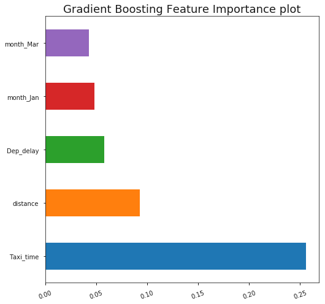

```python
feat_importances = pd.Series(gbc.feature_importances_, index=x_train.columns)
plt.figure(figsize=(8,8))
feat_importances.nlargest(5).plot(kind='barh')
plt.xticks(rotation=20, fontsize = 10)
plt.yticks(fontsize = 10)
plt.title('Gradient Boosting Feature Importance plot')
fig_size = plt.rcParams["figure.figsize"]
```

#### Model Performance - ROC Curves

```python
model_df = pd.read_excel('Model Results.xlsx', index_col= None)
```

```python
model_df.info()
```

```
<class 'pandas.core.frame.DataFrame'>
RangeIndex: 10 entries, 0 to 9
Data columns (total 7 columns):
Model        10 non-null object
AUC          10 non-null float64
Accuracy     10 non-null float64
Recall       10 non-null float64
Precision    10 non-null float64
F1 Score     10 non-null float64
Data         10 non-null object
dtypes: float64(5), object(2)
memory usage: 640.0+ bytes
```

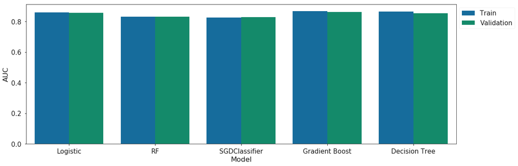

```python
fig = plt.figure(figsize=(18,6))
ax = sns.barplot(x="Model",y="AUC", hue="Data", data=model_df, palette="colorblind")
ax.legend(bbox_to_anchor=(1, 1))
```

```python
from sklearn.metrics import roc_curve
def plot_roc_curve(fpr,tpr,label = None):
    plt.plot(fpr,tpr,linewidth =2,label=label)
    plt.plot([0,1],[0,1],'k--')
    plt.axis([0,1,0,1])
    plt.xlabel('FPR')
    plt.ylabel('TPR')
```

```python
forest_clf = RandomForestClassifier()
y_prob_rf = cross_val_predict(forest_clf,X_val,Y_val,cv=3,method="predict_proba")
y_prob_lr = cross_val_predict(lr_fit,X_val,Y_val,cv=3,method="predict_proba")
y_prob_gb = cross_val_predict(gbc,X_val,Y_val,cv=3,method="predict_proba")
```

```python
y_prob_dt = cross_val_predict(tree,X_val,Y_val,cv=3,method="predict_proba")
y_prob_sgd = cross_val_predict(sgdc,X_val,Y_val,cv=3,method="predict_proba")
```

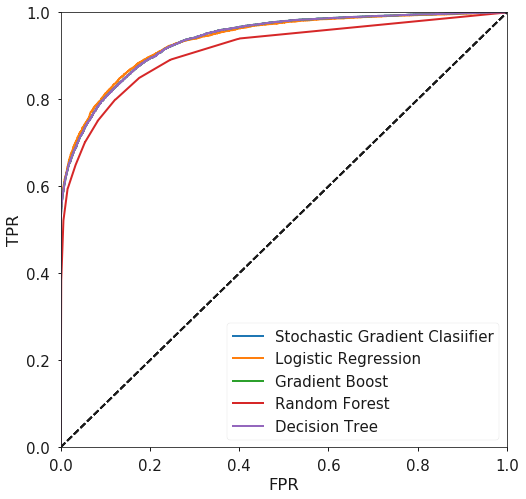

```python
y_scores = y_prob_rf[:,1]
y_scores_lr = y_prob_lr[:,1]
y_scores_gb = y_prob_gb[:,1]
y_scores_dt = y_prob_dt[:,1]
y_scores_sgd= y_prob_sgd[:,1]
fpr_rf,tpr_rf ,thresholds = roc_curve(Y_val,y_scores)
fpr_lr,tpr_lr ,thresholds = roc_curve(Y_val,y_scores_lr)
fpr_gb,tpr_gb ,thresholds = roc_curve(Y_val,y_scores_gb)
fpr_dt,tpr_dt ,thresholds = roc_curve(Y_val,y_scores_dt)
fpr_sgd,tpr_sgd ,thresholds = roc_curve(Y_val,y_scores_sgd)
plt.figure(figsize=(8,8))
plot_roc_curve(fpr_gb,tpr_gb,"Stochastic Gradient Clasiifier")
plot_roc_curve(fpr_lr,tpr_lr,"Logistic Regression")
plot_roc_curve(fpr_gb,tpr_gb,"Gradient Boost")
plot_roc_curve(fpr_rf,tpr_rf,"Random Forest")
plot_roc_curve(fpr_gb,tpr_gb,"Decision Tree")
plt.legend(loc = "lower right")
plt.show()
```

#### Fine Tuning - Grid Search

```python
## Grid Search
from sklearn.model_selection import GridSearchCV
from sklearn.pipeline import Pipeline
pipe = Pipeline([('classifier' , GradientBoostingClassifier())])
param_grid = [
    {'classifier' : [GradientBoostingClassifier()],
    'classifier__n_estimators' : list(range(10,50,10)),
    'classifier__max_features' : list(range(6,32,5))}
]

clf = GridSearchCV(pipe, param_grid = param_grid, cv = 5, verbose=True, n_jobs=-1)
```

```python
clf.fit(x_train,y_train)
```

```
Fitting 5 folds for each of 24 candidates, totalling 120 fits
```

```
[Parallel(n_jobs=-1)]: Done  42 tasks      | elapsed:  2.9min
[Parallel(n_jobs=-1)]: Done 120 out of 120 | elapsed: 10.3min finished
```

```
GridSearchCV(cv=5, error_score='raise',
       estimator=Pipeline(memory=None,
     steps=[('classifier', GradientBoostingClassifier(criterion='friedman_mse', init=None,
              learning_rate=0.1, loss='deviance', max_depth=3,
              max_features=None, max_leaf_nodes=None,
              min_impurity_decrease=0.0, min_impurity_split=...     presort='auto', random_state=None, subsample=1.0, verbose=0,
              warm_start=False))]),
       fit_params=None, iid=True, n_jobs=-1,
       param_grid=[{'classifier': [GradientBoostingClassifier(criterion='friedman_mse', init=None,
              learning_rate=0.1, loss='deviance', max_depth=3,
              max_features=31, max_leaf_nodes=None,
              min_impurity_decrease=0.0, min_impurity_split=None,
              min_samples_l... 'classifier__n_estimators': [10, 20, 30, 40], 'classifier__max_features': [6, 11, 16, 21, 26, 31]}],
       pre_dispatch='2*n_jobs', refit=True, return_train_score='warn',
       scoring=None, verbose=True)
```

```python
clf.best_params_
```

```
{'classifier': GradientBoostingClassifier(criterion='friedman_mse', init=None,
               learning_rate=0.1, loss='deviance', max_depth=3,
               max_features=31, max_leaf_nodes=None,
               min_impurity_decrease=0.0, min_impurity_split=None,
               min_samples_leaf=1, min_samples_split=2,
               min_weight_fraction_leaf=0.0, n_estimators=40,
               presort='auto', random_state=None, subsample=1.0, verbose=0,
               warm_start=False),
 'classifier__max_features': 31,
 'classifier__n_estimators': 40}
```

```python
clf.best_estimator_
```

```
Pipeline(memory=None,
     steps=[('classifier', GradientBoostingClassifier(criterion='friedman_mse', init=None,
              learning_rate=0.1, loss='deviance', max_depth=3,
              max_features=31, max_leaf_nodes=None,
              min_impurity_decrease=0.0, min_impurity_split=None,
              min_samples_leaf=1, min_samples_split=2,
              min_weight_fraction_leaf=0.0, n_estimators=40,
              presort='auto', random_state=None, subsample=1.0, verbose=0,
              warm_start=False))])
```

#### Test Set Predictions

```python
X_test = df_test.drop(['Arr_Target'],axis=1)
Y_test = df_test.Arr_Target
pred = clf.best_estimator_.predict(X_test)
pred_val = clf.best_estimator_.predict(X_val)
```

```python
print_rep(Y_test,pred,thresh = 0.5)
print_rep(Y_val,pred_val,thresh = 0.5)
```

```
AUC:0.849
Accuracy:0.852
Recall:0.841
Specificity:0.857
Precision:0.711
f1Score:0.771

AUC:0.852
Accuracy:0.854
Recall:0.847
Specificity:0.857
Precision:0.717
f1Score:0.777
```

```
(0.8523779535049611,
 0.854416059895512,
 0.8473198291304946,
 0.7166666666666667,
 0.8574360778794277,
 0.776535960093452)
```

```python
pred_gbc_test = gbc.predict(X_test)
print_rep(Y_test,pred_gbc_test,thresh = 0.5)
```

```
AUC:0.858
Accuracy:0.864
Recall:0.843
Specificity:0.873
Precision:0.736
f1Score:0.786
```

```
(0.8580838564809871,
 0.8643300835081656,
 0.8428312665459106,
 0.7359776128482783,
 0.8733364464160636,
 0.7857885164977916)
```